# 🎬 01 — EDA & Hipóteses (PProductions)

Este notebook realiza uma **Análise Exploratória de Dados (EDA)** na base cinematográfica entregue em CSV. O objetivo é entender as principais características dos filmes, levantar hipóteses e orientar a **PProductions** sobre quais tipos de filmes tendem a performar melhor.

> **Entrada esperada**: `data/movies.csv` contendo as colunas: `Series_Title, Released_Year, Certificate, Runtime, Genre, IMDB_Rating, Overview, Meta_score, Director, Star1, Star2, Star3, Star4, No_of_Votes, Gross`.

## 1. Carregamento dos dados

```
Shape: (999, 16)
```

|  | Unnamed: 0 | Series_Title | Released_Year | Certificate | Runtime | Genre | IMDB_Rating | Overview | Meta_score | Director | Star1 | Star2 | Star3 | Star4 | No_of_Votes | Gross |
| --- | --- | --- | --- | --- | --- | --- | --- | --- | --- | --- | --- | --- | --- | --- | --- | --- |
| 0 | 1 | The Godfather | 1972 | A | 175 min | Crime, Drama | 9.2 | An organized crime dynasty's aging patriarch t... | 100.0 | Francis Ford Coppola | Marlon Brando | Al Pacino | James Caan | Diane Keaton | 1620367 | 134,966,411 |
| 1 | 2 | The Dark Knight | 2008 | UA | 152 min | Action, Crime, Drama | 9.0 | When the menace known as the Joker wreaks havo... | 84.0 | Christopher Nolan | Christian Bale | Heath Ledger | Aaron Eckhart | Michael Caine | 2303232 | 534,858,444 |
| 2 | 3 | The Godfather: Part II | 1974 | A | 202 min | Crime, Drama | 9.0 | The early life and career of Vito Corleone in ... | 90.0 | Francis Ford Coppola | Al Pacino | Robert De Niro | Robert Duvall | Diane Keaton | 1129952 | 57,300,000 |

```
<class 'pandas.core.frame.DataFrame'>
RangeIndex: 999 entries, 0 to 998
Data columns (total 16 columns):
 #   Column         Non-Null Count  Dtype
---  ------         --------------  -----
 0   Unnamed: 0     999 non-null    int64
 1   Series_Title   999 non-null    object
 2   Released_Year  999 non-null    object
 3   Certificate    898 non-null    object
 4   Runtime        999 non-null    object
 5   Genre          999 non-null    object
 6   IMDB_Rating    999 non-null    float64
 7   Overview       999 non-null    object
 8   Meta_score     842 non-null    float64
 9   Director       999 non-null    object
 10  Star1          999 non-null    object
 11  Star2          999 non-null    object
 12  Star3          999 non-null    object
 13  Star4          999 non-null    object
 14  No_of_Votes    999 non-null    int64
 15  Gross          830 non-null    object
dtypes: float64(2), int64(2), object(12)
memory usage: 125.0+ KB
```

|  | count | mean | std | min | 25% | 50% | 75% | max |
| --- | --- | --- | --- | --- | --- | --- | --- | --- |
| Unnamed: 0 | 999.0 | 500.000000 | 288.530761 | 1.0 | 250.5 | 500.0 | 749.5 | 999.0 |
| IMDB_Rating | 999.0 | 7.947948 | 0.272290 | 7.6 | 7.7 | 7.9 | 8.1 | 9.2 |
| Meta_score | 842.0 | 77.969121 | 12.383257 | 28.0 | 70.0 | 79.0 | 87.0 | 100.0 |
| No_of_Votes | 999.0 | 271621.422422 | 320912.621055 | 25088.0 | 55471.5 | 138356.0 | 373167.5 | 2303232.0 |

## 2. Limpeza & Parsing de colunas

Transformações principais:

- **Runtime** → minutos (inteiro)
- **Gross** → número (float), removendo separadores
- **Released_Year** → inteiro
- **Genre** → lista de gêneros + gênero principal (`Genre_Primary`)

|  | Unnamed: 0 | Series_Title | Released_Year | Certificate | Runtime | Genre | IMDB_Rating | Overview | Meta_score | Director | Star1 | Star2 | Star3 | Star4 | No_of_Votes | Gross | Runtime_min | Gross_num | Released_Year_int | Genre_List | Genre_Primary |
| --- | --- | --- | --- | --- | --- | --- | --- | --- | --- | --- | --- | --- | --- | --- | --- | --- | --- | --- | --- | --- | --- |
| 0 | 1 | The Godfather | 1972 | A | 175 min | Crime, Drama | 9.2 | An organized crime dynasty's aging patriarch t... | 100.0 | Francis Ford Coppola | Marlon Brando | Al Pacino | James Caan | Diane Keaton | 1620367 | 134,966,411 | 175 | 134966411.0 | 1972 | [Crime, Drama] | Crime |
| 1 | 2 | The Dark Knight | 2008 | UA | 152 min | Action, Crime, Drama | 9.0 | When the menace known as the Joker wreaks havo... | 84.0 | Christopher Nolan | Christian Bale | Heath Ledger | Aaron Eckhart | Michael Caine | 2303232 | 534,858,444 | 152 | 534858444.0 | 2008 | [Action, Crime, Drama] | Action |
| 2 | 3 | The Godfather: Part II | 1974 | A | 202 min | Crime, Drama | 9.0 | The early life and career of Vito Corleone in ... | 90.0 | Francis Ford Coppola | Al Pacino | Robert De Niro | Robert Duvall | Diane Keaton | 1129952 | 57,300,000 | 202 | 57300000.0 | 1974 | [Crime, Drama] | Crime |

|  | missing_ratio |
| --- | --- |
| Gross_num | 0.169169 |
| Gross | 0.169169 |
| Meta_score | 0.157157 |
| Certificate | 0.101101 |
| Released_Year_int | 0.001001 |
| Unnamed: 0 | 0.000000 |
| Star3 | 0.000000 |
| Genre_List | 0.000000 |
| Runtime_min | 0.000000 |
| No_of_Votes | 0.000000 |
| Star4 | 0.000000 |
| Star1 | 0.000000 |
| Star2 | 0.000000 |
| Series_Title | 0.000000 |
| Director | 0.000000 |

## 3. Distribuições básicas

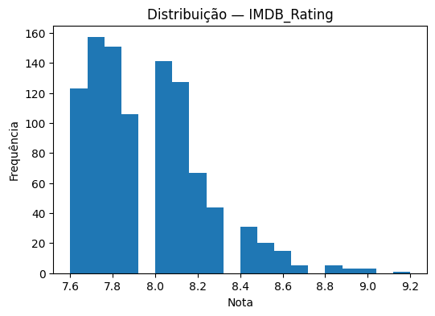

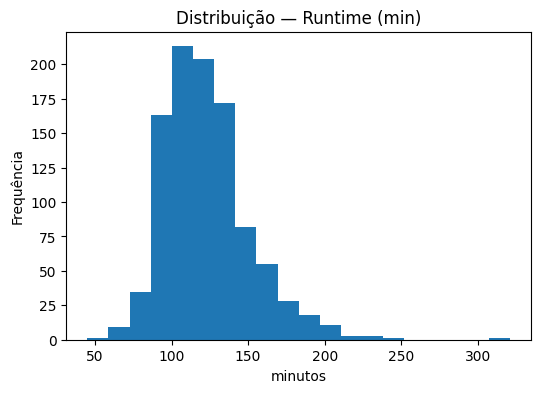

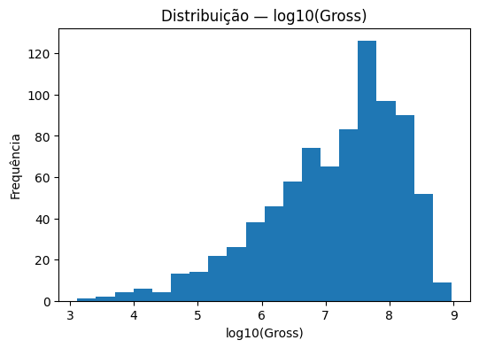

## 4. Relações entre variáveis

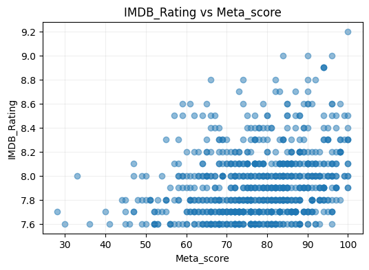

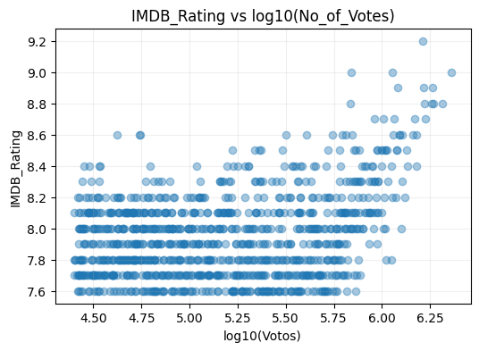

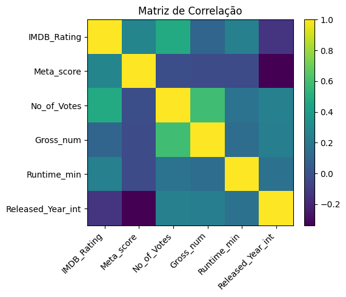

|  | IMDB_Rating | Meta_score | No_of_Votes | Gross_num | Runtime_min | Released_Year_int |
| --- | --- | --- | --- | --- | --- | --- |
| IMDB_Rating | 1.000000 | 0.271374 | 0.479308 | 0.099393 | 0.242751 | -0.133257 |
| Meta_score | 0.271374 | 1.000000 | -0.020091 | -0.030480 | -0.031604 | -0.339291 |
| No_of_Votes | 0.479308 | -0.020091 | 1.000000 | 0.589527 | 0.172483 | 0.246005 |
| Gross_num | 0.099393 | -0.030480 | 0.589527 | 1.000000 | 0.140002 | 0.233270 |
| Runtime_min | 0.242751 | -0.031604 | 0.172483 | 0.140002 | 1.000000 | 0.165765 |
| Released_Year_int | -0.133257 | -0.339291 | 0.246005 | 0.233270 | 0.165765 | 1.000000 |